# assignment4

na

November 14, 2018

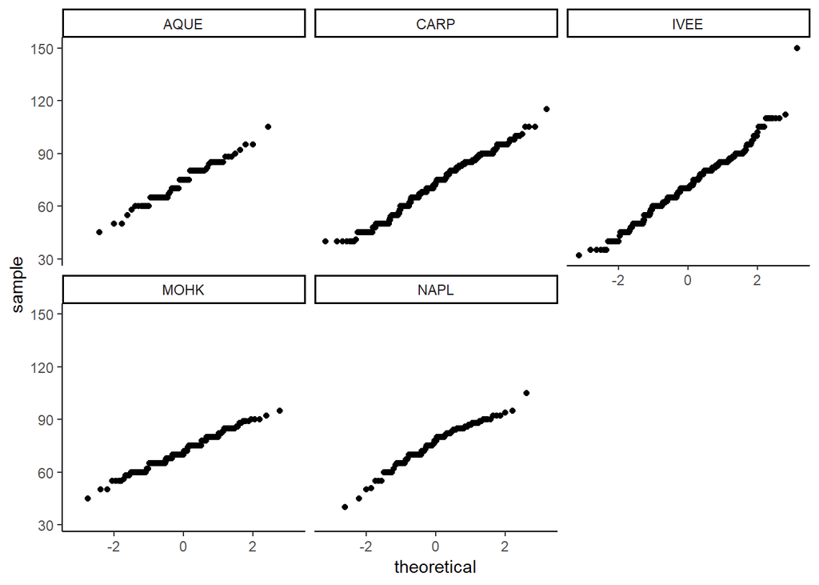

```r
#___________________________________part 2___________________________________#

# filter for only 2017
lsa_filt2017 <- lsa_filt %>%
  filter(YEAR == 2017)

# look at site distributions
qq_site_means <- ggplot(lsa_filt2017, aes(sample = SIZE)) +
  geom_qq() +
  facet_wrap(~ SITE) +
  theme_classic()
qq_site_means
```

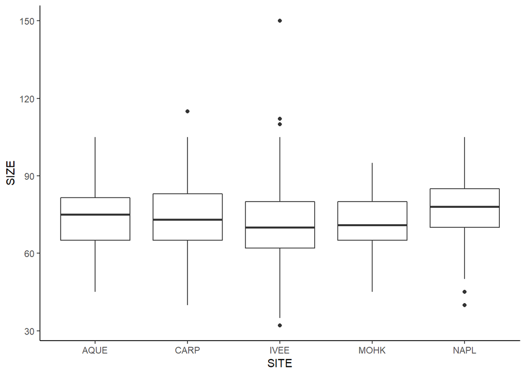

```r
box_site_means <- ggplot(lsa_filt2017, aes(x = SITE, y = SIZE)) +
  geom_boxplot() +
  theme_classic()
box_site_means
```

```r
# convert site to factor in lsa_filt
lsa_filt2017$SITE <- as.factor(lsa_filt2017$SITE)

# find site means, variance, etc.
lsa_site_means <- lsa_filt2017 %>%
  group_by(MPA, SITE) %>%
  summarize(
    mean_size = mean(SIZE),
    sd_size = sd(SIZE),
    var_size = var(SIZE),
    n = length(SIZE)
  ) %>%
  arrange(MPA) %>%
  mutate(yloc = mean_size + sd_size + 3.5) # loc of annotation

lsa_site_means$SITE <- factor(lsa_site_means$SITE, levels = c("IVEE","NAPL","AQUE","MOHK","CARP"))


# levines test for equal variances
lsa_levine <- leveneTest(SIZE ~ SITE, data = lsa_filt2017)
lsa_levine
```

```
## Levene's Test for Homogeneity of Variance (center = median)
##         Df F value    Pr(>F)
## group    4  8.3893 1.065e-06 ***
##       1663
## ---
## Signif. codes:  0 '***' 0.001 '**' 0.01 '*' 0.05 '.' 0.1 ' ' 1
```

```r
# anova with unequal variances
lsa_aov_size_site <- oneway(lsa_filt2017$SITE, y = lsa_filt2017$SIZE, posthoc = 'games-howell', corrections = F, levene = T)
lsa_aov_size_site
```

```
## ### Oneway Anova for y=SIZE and x=SITE (groups: AQUE, CARP, IVEE, MOHK, NAPL)
##
## Omega squared: 95% CI = [0; .02], point estimate = .01
## Eta Squared: 95% CI = [0; .01], point estimate = .01
##
##                                        SS   Df     MS    F    p
## Between groups (error + effect)   2354.51    4 588.63 3.42 .009
## Within groups (error only)      285871.12 1663  171.9
##
##
## ### Levene's test for homogeneity of variance:
##
## F[4, 1663] = 8.77, p < .001.
##
## ### Post hoc test: games-howell
##
##            diff ci.lo ci.hi    t      df    p
## CARP-AQUE -1.67 -5.95  2.62 1.08   82.28 .814
## IVEE-AQUE -2.44 -6.80  1.91 1.56   88.61 .526
## MOHK-AQUE -1.90 -6.37  2.58 1.18   97.81 .765
## NAPL-AQUE  2.34 -2.66  7.34 1.29  134.26 .696
## IVEE-CARP -0.78 -2.87  1.31 1.02 1242.45 .848
## MOHK-CARP -0.23 -2.57  2.11 0.27  379.43 .999
## NAPL-CARP  4.00  0.73  7.27 3.38  162.35 .008
## MOHK-IVEE  0.55 -1.94  3.03 0.60  447.17 .974
## NAPL-IVEE  4.78  1.41  8.15 3.91  182.49 .001
## NAPL-MOHK  4.23  0.71  7.76 3.30  201.12 .010
```

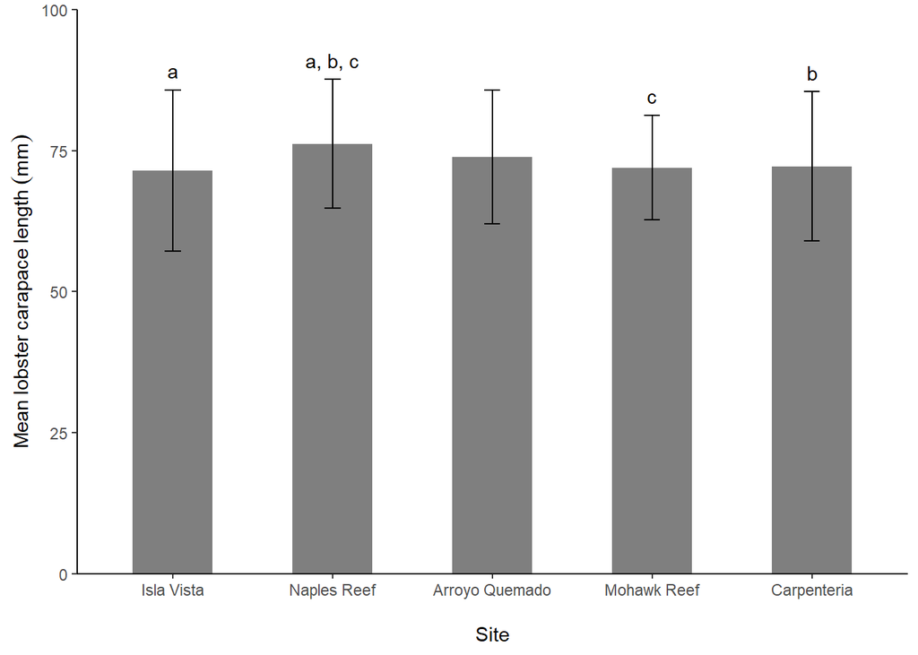

```r
# y loc for annotations
yloc_i <- lsa_site_means %>%
  filter(SITE == "IVEE") %>%
  pull(yloc)

yloc_n <- lsa_site_means %>%
  filter(SITE == "NAPL") %>%
  pull(yloc)

yloc_c <- lsa_site_means %>%
  filter(SITE == "CARP") %>%
  pull(yloc)

yloc_m <- lsa_site_means %>%
  filter(SITE == "MOHK") %>%
  pull(yloc)


#___________________plot___________________#
lsa_aov_colplt <- ggplot(lsa_site_means, aes(x = SITE, y = mean_size)) +
  geom_col(fill = "gray50", width = 0.5) +
  theme_classic() +
  geom_errorbar(aes(ymax =mean_size + sd_size, ymin = mean_size - sd_size), width = 0.1) +
  scale_y_continuous(expand = c(0,0), limits = c(0,100)) +
  labs(y=expression(Mean~lobster~carapace~length~(mm))) +
  scale_x_discrete(labels = c("Isla Vista","Naples Reef","Arroyo Quemado","Mohawk Reef", "Carpenteria")) +
  annotate("text", x = c(1), y = yloc_i, label = "a") +
  annotate("text", x = c(2), y = yloc_n, label = "a, b, c") +
  annotate("text", x = c(5), y = yloc_c, label = "b") +
  annotate("text", x = c(4), y = yloc_m, label = "c") +
  xlab("\nSite")
lsa_aov_colplt
```

```r
ggsave(filename = "colplotlobstersize.png", plot = lsa_aov_colplt,
  scale = 1, width = 6, height = 4.5, units = "in",
  dpi = 300)

#___________________table___________________#
lsa_aov_tabledf <- lsa_site_means %>%
  ungroup() %>%
  mutate(sitel = case_when(
    SITE == "IVEE" ~ "Isla Vista",
    SITE == "NAPL" ~ "Naples Reef",
    SITE == "AQUE" ~ "Arroyo Quemado",
    SITE == "CARP" ~ "Carpinteria",
    SITE == "MOHK" ~ "Mohawk Reef")
    ) %>%
  select(sitel, mean_size, sd_size, n)

lsa_aov_table <- kable(lsa_aov_tabledf,
                       format = "markdown",
                       caption = "Table 1. Mean and standard deviation of lobster carapace length at five California sites in 2017. Source: Santa   Barbara Coastal Long Term Ecological Research Project.",
                       col.names=c('Site',
                                   'Mean carapace length (mm)',
                                   'Standard deviation of carapace length (mm)',
                                   'n'),
                       digits=2)
lsa_aov_table
```

| Site | Mean carapace length (mm) | Standard deviation of carapace length (mm) | n |
| --- | --- | --- | --- |
| Arroyo Quemado | 73.90 | 11.89 | 67 |
| Carpinteria | 72.23 | 13.21 | 705 |
| Mohawk Reef | 72.00 | 9.28 | 178 |
| Isla Vista | 71.45 | 14.32 | 606 |
| Naples Reef | 76.23 | 11.39 | 112 |

Significance result for MPA t.test between 2012 and 2017: (t(748) = -1.916, p = 0.056, $\alpha$ = 0.05)

Significance result for nonMPA t.test between 2012 and 2017: (t(1147) = 2.697, p = 0.007, $\alpha$ = 0.05) effect size small: (Cohen’s $d$ = 0.21)

```r
#___________________________________part 4___________________________________#
#Proportions of “legal” lobsters at the 5 sites in 2017
#The legal minimum carapace size for lobster is 82.6 mm

lsa_legal <- lsa_filt2017 %>%
  mutate(legal = case_when(
    SIZE > 82.6 ~ "y",
         SIZE < 82.6 ~ "n"))


sum_legal <- lsa_legal %>%
  group_by(SITE) %>%
  filter (legal == "y") %>%
  summarize(
    legal = length(legal))

sum_illegal <- lsa_legal %>%
  group_by(SITE) %>%
  filter (legal == "n") %>%
  summarize(
    illegal = length(legal))

legal_joined <- left_join(sum_legal, sum_illegal, by = "SITE") %>%
  select(legal, illegal)

rownames(legal_joined) <- c('Arroyo Quemado', 'Carpenteria', 'Isla Vista', 'Mohawk Reef', 'Naples Reef')
#legal_table <- legal_joined create matrix

prop <- prop.table(as.matrix(legal_joined), 1)

prop_rounded <- round (prop, 2) #Round proportions to 2 digits
prop_rounded
```

```
##                legal illegal
## Arroyo Quemado  0.24    0.76
## Carpenteria     0.25    0.75
## Isla Vista      0.21    0.79
## Mohawk Reef     0.13    0.87
## Naples Reef     0.33    0.67
```

```r
prop_table <- kable(prop_rounded,
                    format = "markdown",
                    caption = "Table 2. Proportion of lobsters that are above the legal minimum carapace size for lobster (82.6 mm) at five California sites in 2017. Source: Santa Barbara Coastal Long Term Ecological Research Project.",
      col.names = c('Proportion Above Minimum Size', 'Proportion Below Min Size'))

prop_table
```

|  | Proportion Above Minimum Size | Proportion Below Min Size |
| --- | --- | --- |
| Arroyo Quemado | 0.24 | 0.76 |
| Carpenteria | 0.25 | 0.75 |
| Isla Vista | 0.21 | 0.79 |
| Mohawk Reef | 0.13 | 0.87 |
| Naples Reef | 0.33 | 0.67 |

```r
legal_chi <- chisq.test(legal_joined)
legal_chi
```

```
##
##  Pearson's Chi-squared test
##
## data:  legal_joined
## X-squared = 18.497, df = 4, p-value = 0.0009864
```

A greater proportion of lobsters are below the legal minimum carapace size than above for all locations. The proportion of legal sized lobsters is smallest at Mohawk Reef as there is rougly 7 times more lobsters as this site that do not meet the legal minimum size. Naples Reef has the largest proportion of legal sized lobsters, roughly half that of the proportion of lobsters below the minimum size.

**Research Question**: Is there an association between site and proportion of “legal” lobsters?

#### Hypothesis Testing & Chi Square

Null Hypothesis: Location is independent of proportions of lobsters that are above the legal minimum. Alternative Hypothesis: Proportions of lobsters that are above the minimum size requirement are significantly different between sites.

**Conclusion**: Proportions of lobsters that are above the minimum size requirement differs significantly by site ($\chi$<sup>2</sup>(4) = 18.497, *p* < 0.001, $\alpha$ = 0.05).

```r
legal_chi$observed
```

```
##                legal illegal
## Arroyo Quemado    16      51
## Carpenteria      179     526
## Isla Vista       130     476
## Mohawk Reef       24     154
## Naples Reef       37      75
```

```r
round(legal_chi$expected,0)
```

```
##                legal illegal
## Arroyo Quemado    16      51
## Carpenteria      163     542
## Isla Vista       140     466
## Mohawk Reef       41     137
## Naples Reef       26      86
```

```r
legal_chi$stdres #if standardized residuals are >2 this might be driving the significant finding
```

```
##                     legal    illegal
## Arroyo Quemado  0.1464223 -0.1464223
## Carpenteria     1.8631463 -1.8631463
## Isla Vista     -1.2357993  1.2357993
## Mohawk Reef    -3.2327773  3.2327773
## Naples Reef     2.5706474 -2.5706474
```

Naples and Mohawk Reefs might be driving significance.

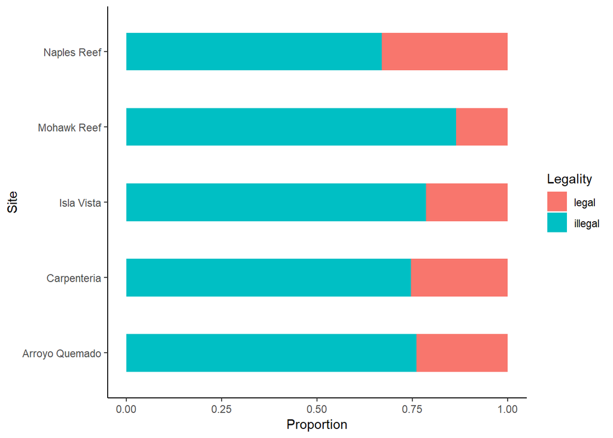

```r
legal_expand <- data.frame(expand.grid(rownames(prop), colnames(prop)), value = c(prop)) # moves from a contigency table format to an expanded table format where we can expand either row or column and then by what value

colnames(legal_expand) <- c("Site","Legality","Proportion")
View(legal_expand)

stacked_legal <- ggplot(legal_expand, aes(x = Site, y = Proportion)) +
  geom_col(aes(fill = Legality), width = 0.5) +
  theme_classic() +
  coord_flip()

stacked_legal
```